# Bayesian GLM Part1

When doing so, ideally the posterior should be distinct from the prior. If this is not the case, it might suggest that the posteriors are being too strongly driven by the priors.

```r
fert_brm3 |> get_variables()
```

```
 [1] "b_Intercept"       "b_scaleFERTILIZER" "sigma"
 [4] "Intercept"         "prior_Intercept"   "prior_b"
 [7] "prior_sigma"       "lprior"            "lp__"
[10] "accept_stat__"     "stepsize__"        "treedepth__"
[13] "n_leapfrog__"      "divergent__"       "energy__"
```

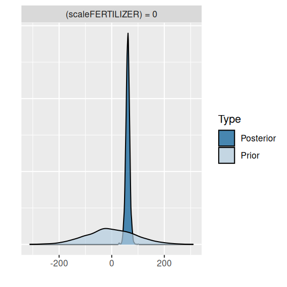

```r
## fert_brm3 |> hypothesis('Intercept=0', class='b') |> plot
fert_brm3 |>
  hypothesis("scaleFERTILIZER = 0") |>
  plot()
```

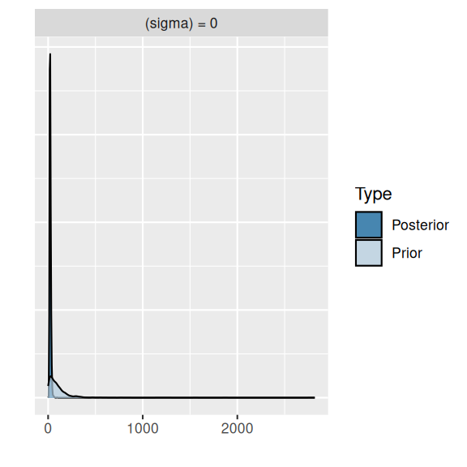

```r
## fert_brm3 |> hypothesis('scaleFERTILIZERscaleEQFALSE=0') |> plot
fert_brm3 |>
  hypothesis("sigma = 0", class = "") |>
  plot()
```

```r
fert_brm3 |> get_variables()
```

```
 [1] "b_Intercept"       "b_scaleFERTILIZER" "sigma"
 [4] "Intercept"         "prior_Intercept"   "prior_b"
 [7] "prior_sigma"       "lprior"            "lp__"
[10] "accept_stat__"     "stepsize__"        "treedepth__"
[13] "n_leapfrog__"      "divergent__"       "energy__"
```

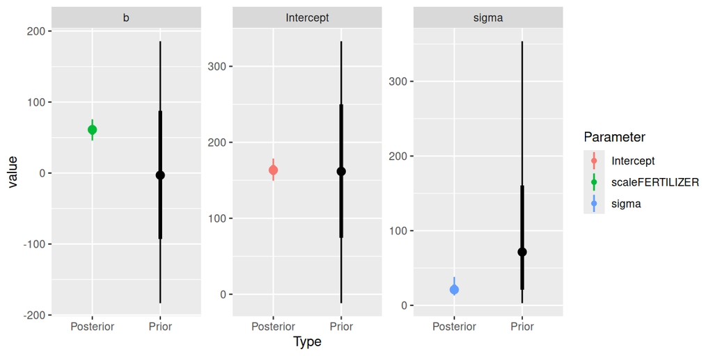

```r
fert_brm3 |> SUYR_prior_and_posterior()
```

**Exploring the stan code**

```r
fert_brm3 |> standata()
```

```
$N
[1] 10

$Y
 [1]  84  80  90 154 148 169 206 244 212 248

$K
[1] 2

$Kc
[1] 1

$X
   Intercept scaleFERTILIZER
1          1      -1.4863011
2          1      -1.1560120
3          1      -0.8257228
4          1      -0.4954337
5          1      -0.1651446
6          1       0.1651446
7          1       0.4954337
8          1       0.8257228
9          1       1.1560120
10         1       1.4863011
attr(,"assign")
[1] 0 1

$prior_only
[1] 0

attr(,"class")
[1] "standata" "list"
```

```r
fert_brm3 |> stancode()
```

```
// generated with brms 2.22.0
functions {
}
data {
  int<lower=1> N;  // total number of observations
  vector[N] Y;  // response variable
  int<lower=1> K;  // number of population-level effects
  matrix[N, K] X;  // population-level design matrix
  int<lower=1> Kc;  // number of population-level effects after centering
  int prior_only;  // should the likelihood be ignored?
}
transformed data {
  matrix[N, Kc] Xc;  // centered version of X without an intercept
  vector[Kc] means_X;  // column means of X before centering
  for (i in 2:K) {
    means_X[i - 1] = mean(X[, i]);
    Xc[, i - 1] = X[, i] - means_X[i - 1];
  }
}
parameters {
  vector[Kc] b;  // regression coefficients
  real Intercept;  // temporary intercept for centered predictors
  real<lower=0> sigma;  // dispersion parameter
}
transformed parameters {
  real lprior = 0;  // prior contributions to the log posterior
  lprior += normal_lpdf(b | 0, 90);
  lprior += normal_lpdf(Intercept | 162, 90.4);
  lprior += student_t_lpdf(sigma | 3, 0, 90.4)
    - 1 * student_t_lccdf(0 | 3, 0, 90.4);
}
model {
  // likelihood including constants
  if (!prior_only) {
    target += normal_id_glm_lpdf(Y | Xc, Intercept, b, sigma);
  }
  // priors including constants
  target += lprior;
}
generated quantities {
  // actual population-level intercept
  real b_Intercept = Intercept - dot_product(means_X, b);
  // additionally sample draws from priors
  real prior_b = normal_rng(0,90);
  real prior_Intercept = normal_rng(162,90.4);
  real prior_sigma = student_t_rng(3,0,90.4);
  // use rejection sampling for truncated priors
  while (prior_sigma < 0) {
    prior_sigma = student_t_rng(3,0,90.4);
  }
}
```

**INLA**

**Using default priors**

In `INLA`, the default priors are designed to be diffuse or weak. They are chosen to provide moderate regularisation (to help prevent over-fitting) and help stabilise the computations.

** Note as of mid 2022, the INLA developers have intentionally disabled the calculation of marginals in order to make the models faster**. Unfortunately, this prevents the calculation of residuals from the `INLAutils` package. So I will turn them on… More info can be viewed here https://groups.google.com/g/r-inla-discussion-group/c/2E9z3QfmeXw/m/XB0PoLqEBAAJ?pli=1

```r
fert.inla <- inla(YIELD ~ FERTILIZER,
  data = fert,
  family = "gaussian",
  control.predictor = list(compute = TRUE, link = 1),
  control.compute = list(
    config = TRUE,
    dic = TRUE, waic = TRUE, cpo = TRUE,
    return.marginals.predictor = TRUE
  )
)
```

In the above:

- the `formula`, `data` and `family` arguments should be familiar as they are the same as for other models in R.
- `control.compute`: allows us to indicate what additional actions should be performed during the model fitting. In this case, we have indicated:
  - `dic`: Deviance information criterion
  - `waic`: Wantanabe information creterion
  - `cpo`: out-of-sample estimates (measures of fit)
  - `config`: return the full configuration - to allow drawing from the posterior.

```r
fert.inla |> names()
```

```
 [1] "names.fixed"                 "summary.fixed"
 [3] "marginals.fixed"             "summary.lincomb"
 [5] "marginals.lincomb"           "size.lincomb"
 [7] "summary.lincomb.derived"     "marginals.lincomb.derived"
 [9] "size.lincomb.derived"        "mlik"
[11] "cpo"                         "gcpo"
[13] "po"                          "waic"
[15] "residuals"                   "model.random"
[17] "summary.random"              "marginals.random"
[19] "size.random"                 "summary.linear.predictor"
[21] "marginals.linear.predictor"  "summary.fitted.values"
[23] "marginals.fitted.values"     "size.linear.predictor"
[25] "summary.hyperpar"            "marginals.hyperpar"
[27] "internal.summary.hyperpar"   "internal.marginals.hyperpar"
[29] "offset.linear.predictor"     "model.spde2.blc"
[31] "summary.spde2.blc"           "marginals.spde2.blc"
[33] "size.spde2.blc"              "model.spde3.blc"
[35] "summary.spde3.blc"           "marginals.spde3.blc"
[37] "size.spde3.blc"              "logfile"
[39] "misc"                        "dic"
[41] "mode"                        "joint.hyper"
[43] "nhyper"                      "version"
[45] "Q"                           "graph"
[47] "ok"                          "cpu.intern"
[49] "cpu.used"                    "all.hyper"
[51] ".args"                       "call"
[53] "model.matrix"
```

Having allowed `INLA` to formulate its own “minimally informative” priors, it is a good idea to explore what they are. Firstly, out of curiosity, it might be interesting to see what it has chosen. However, more importantly, we need to be able to document what the priors were and the `INLA` development team make it very clear that there is no guarantee that the default priors will remain the same into the future.

In calcutating the posterior mode of hyperparameters, it is efficient to maximising the sum of the (log)-likelihood and the (log)-prior, hence, priors are defined on a log-scale. The canonical prior for variance is the *gamma* prior, hence in `INLA`, this is a *loggamma*.

To explore the default priors used by `INLA`, we can issue the following on the fitted model:

```r
inla.priors.used(fert.inla)
```

```
section=[family]
    tag=[INLA.Data1] component=[gaussian]
        theta1:
            parameter=[log precision]
            prior=[loggamma]
            param=[1e+00, 5e-05]
section=[fixed]
    tag=[(Intercept)] component=[(Intercept)]
        beta:
            parameter=[(Intercept)]
            prior=[normal]
            param=[0, 0]
    tag=[FERTILIZER] component=[FERTILIZER]
        beta:
            parameter=[FERTILIZER]
            prior=[normal]
            param=[0.000, 0.001]
```

The above indicates:

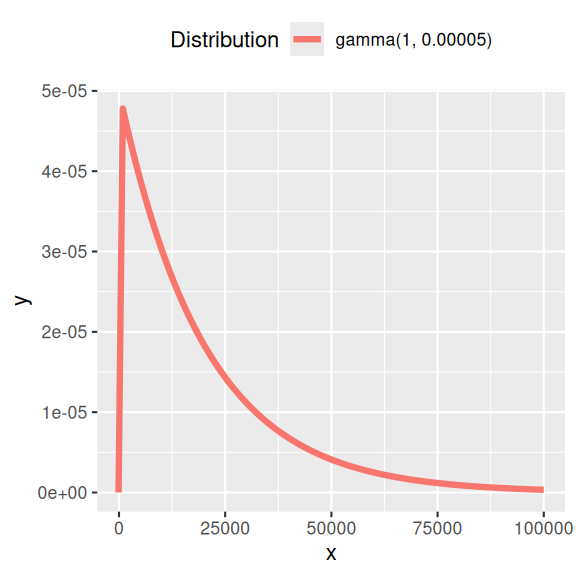

```r
standist::visualize("gamma(1, 0.00005)", xlim=c(-100,100000))
```

- the prior on the intercept is a Gaussian (normal) distribution with mean of 0 and precision of 0 - this is effectively a uniform distribution from $-\infty$ to $\infty$.
- the prior on the slope is a Gaussian (normal) distribution with a mean of 0 and a precision of 0.001 (which equates to a standard deviation of $(1/0.001)^{0.5}$=31.6227766. This is also a very wide distribution (consider what a slope large in magnitude of 100 means in the context of the rate of grass yield increase per unit increase in fertiliser concentration).

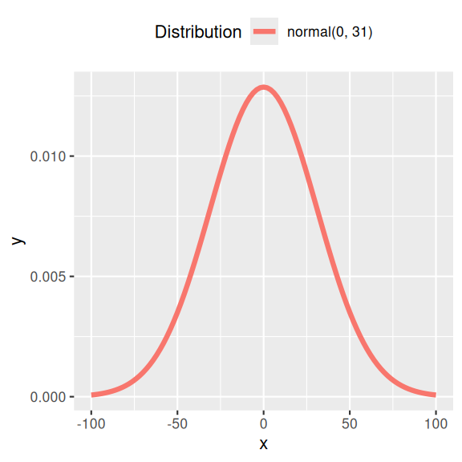

```r
standist::visualize("normal(0, 31)", xlim=c(-100,100))
```

**Defining own priors**

**Family variance**

In order to drive the specification of weekly informative priors for variance components (a prior that allows the data to dictate the parameter estimates whilst constraining the range of the marginal distribution within sensible bounds), we can consider the range over which the marginal distribution of variance components would be sensible. For the range [-R,R], the equivalent gamma parameters:

$$\begin{align}
a &= \frac{d}{2}\\
b &= \frac{R^2d}{2*(t^d_{1-(1-q)/2})^2}
\end{align}$$

where $d$ is the degrees of freedom (for Cauchy marginal, $d=1$) and $t^d_{1-(1-q)/2}$ is the $q_{th}$ quantile of a Student t with $d$ degrees of freedom. Hence if we considered variance likely to be in the range of [0,100], we could define a loggamma prior of:

$$\begin{align}
a &= \frac{1}{2} = 0.5\\
b &= \frac{100^2}{2*161.447} = 30.9\\
\tau &\sim{} log\Gamma(0.5,30.9)
\end{align}$$

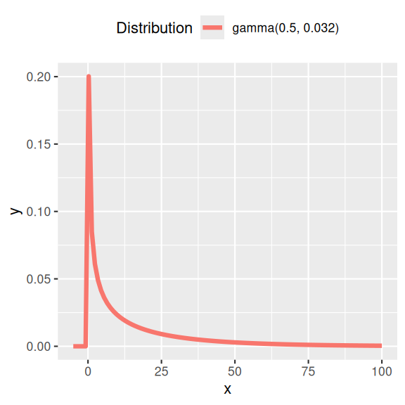

```r
standist::visualize("gamma(0.5, 0.032)", xlim=c(-5,100))
```

**Intercept**

```r
min(fert$YIELD)
```

```
[1] 80
```

```r
median(fert$YIELD)
```

```
[1] 161.5
```

```r
mad(fert$YIELD)
```

```
[1] 90.4386
```

We will multiply the variability (90.4386) by 3 so as to estimate an envelope that so as to fully capture the full range of expected values (271.3158.

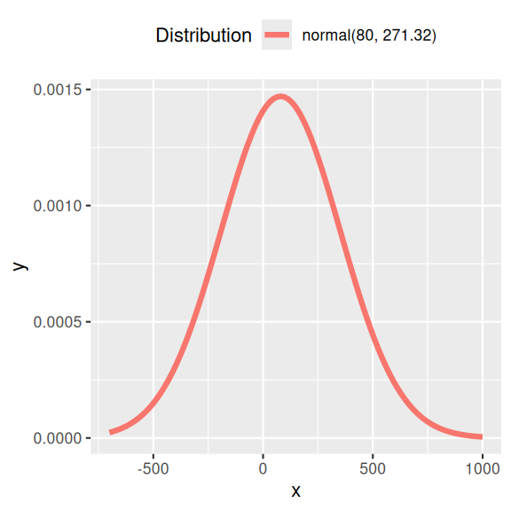

```r
standist::visualize("normal(80, 271.32)", xlim=c(-700,1000))
```

We could use these values as the basis for weekly informative priors on the intercept. Note, as `INLA` priors are expressed in terms of precision rather than variance, an equvilent prior would be $\sim{}~\mathcal{N}(80, 0.00001)$ (e.g. $1/(MAD\times 3)^2$).

**Fixed effects**

The priors for the fixed effects (slope) is a Gaussian (normal) distributions with mean of 0 and precision (0.001). This implies that the prior for slope has a standard deviation of approximately 31 (since $\sigma = \frac{1}{\sqrt{\tau}}$). As a general rule, three standard deviations envelopes most of a distribution, and thus this prior defines a distribution whose density is almost entirely within the range [-93,93]. Arguably, this is very wide for the slope given the range of the predictor variable.

In order to generate realistic informative Gaussian priors (for the purpose of constraining the posterior to a logical range) for fixed parameters, the following formulae are useful:

$$\begin{align}
\mu &= \frac{z_2\theta_1 - z_1\theta_2}{z_2-z_1}\\
\sigma &= \frac{\theta_2 - \theta_1}{z_2-z_1}
\end{align}$$

where $\theta_1$ and $\theta_2$ are the quantiles on the response scale and $z_1$ and $z_2$ are the corresponding quantiles on the standard normal scale. Hence, if we considered that the slope is likely to be in the range of [-10,10], we could specify a Normal prior with mean of $\mu=\frac{(qnorm(0.5,0,1)*0) - (qnorm(0.975,0,1)*10)}{10-0} = 0$ and a standard deviation of $\sigma^2=\frac{10 - 0}{qnorm(0.975,0,1)-qnorm(0.5,0,1)} = 5.102$. In INLA (which defines priors in terms of precision rather than standard deviation), the associated prior would be $\beta \sim{} \mathcal{N}(0, 0.0384)$.

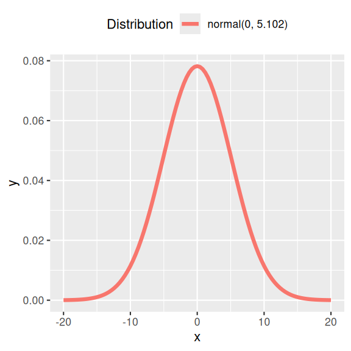

```r
standist::visualize("normal(0, 5.102)", xlim=c(-20,20))
```

In order to define each of the above priors, we could modify the `inla` call:

```r
fert.inla1 <- inla(YIELD ~ FERTILIZER,
  data = fert,
  family = "gaussian",
  control.fixed = list(
    mean.intercept = 80,
    prec.intercept = 0.00001,
    mean = 0,
    prec = 0.0384
  ),
  control.predictor = list(compute = TRUE, link = 1),
  control.family = list(hyper = list(prec = list(
    prior = "loggamma",
    param = c(0.5, 0.032)
  ))),
  control.compute = list(
    config = TRUE,
    return.marginals.predictor = TRUE,
    dic = TRUE,
    waic = TRUE,
    cpo = TRUE
  )
)
```

Lets briefly compare the parameter estimates. In the following, `Model.1` is the model that employed the default priors and `Model.2` is the model that employed the user defined priors.

```r
## Fixed effects
rbind(Model.1 = fert.inla$summary.fixed, Model.2 = fert.inla1$summary.fixed)
```

```
                          mean          sd 0.025quant   0.5quant 0.975quant
Model.1.(Intercept) 51.9340762 12.64763106 26.6632595 51.9339972 77.2053846
Model.1.FERTILIZER   0.8113885  0.08153394  0.6484749  0.8113891  0.9742986
Model.2.(Intercept) 52.0169173 13.48574303 25.0491429 52.0071044 79.0461379
Model.2.FERTILIZER   0.8108657  0.08695558  0.6365844  0.8109277  0.9847584
                         mode          kld
Model.1.(Intercept) 51.934013 4.155607e-06
Model.1.FERTILIZER   0.811389 4.155455e-06
Model.2.(Intercept) 52.009272 7.506730e-06
Model.2.FERTILIZER   0.810914 7.568462e-06
```

```r
## Family hyperpriors (variance)
rbind(Model.1 = fert.inla$summary.hyperpar, Model.2 = fert.inla1$summary.hyperpar)
```

```
               mean          sd   0.025quant    0.5quant  0.975quant
Model.1 0.003463372 0.001543917 0.0011479418 0.003235830 0.007093335
Model.2 0.003118776 0.001463764 0.0009644277 0.002891328 0.006590397
               mode
Model.1 0.002778790
Model.2 0.002416532
```

It is clear that the two models yeild very similar parameter estimates.

**Plotting prior vs posterior**

Note, the following will not appear in this tutorial as the INLA plotting function has been really awkwardly written and is not compatible with Rmd.

```r
plot(fert.inla1,
  plot.fixed.effects = TRUE,
  plot.lincomb = FALSE,
  plot.random.effects = FALSE,
  plot.hyperparameters = TRUE,
  plot.predictor = FALSE,
  plot.q = FALSE,
  plot.cpo = FALSE,
  plot.prior = TRUE,
  single = FALSE
)
```

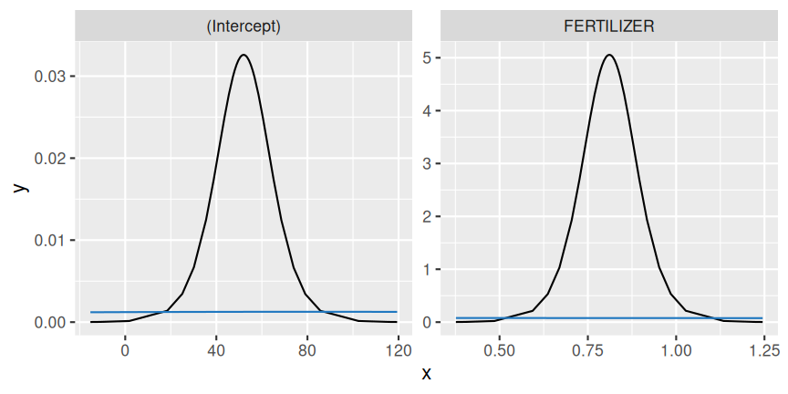

```r
plot_fixed_marginals(fert.inla1, priors = TRUE)
```

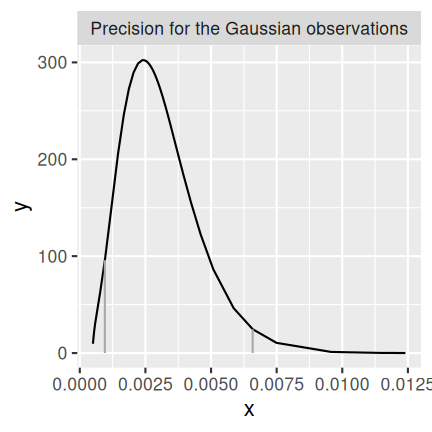

```r
library(INLAutils)
plot_hyper_marginals(fert.inla1, CI = TRUE)
```

Or the effects as a single figure..

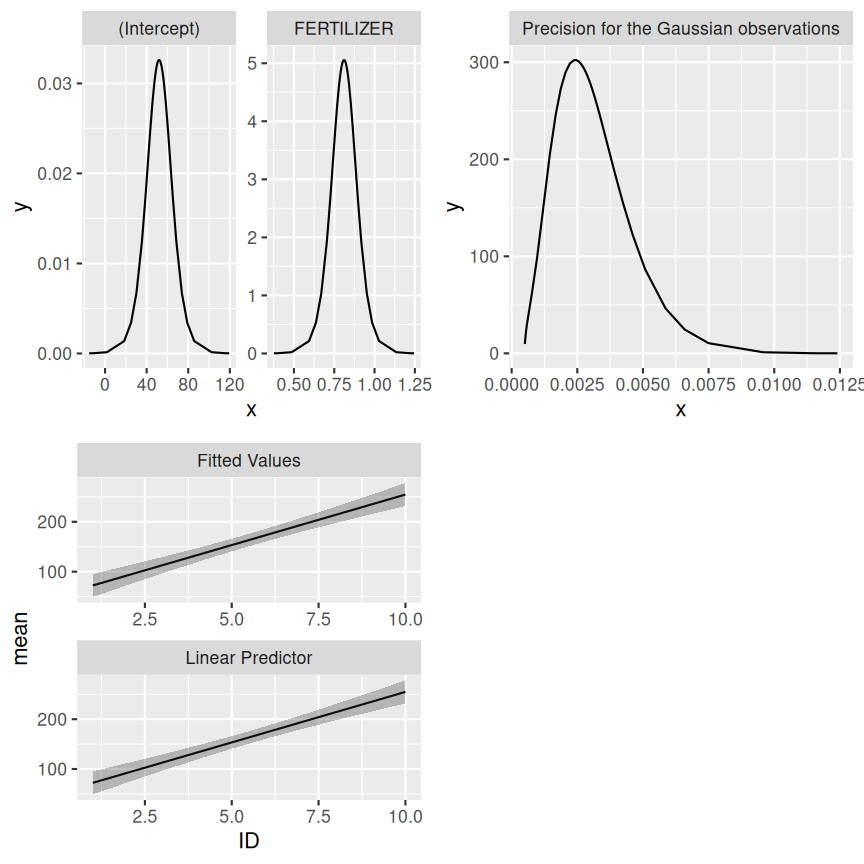

```r
library(INLAutils)
autoplot(fert.inla1)
```

```r
marg.fix <- fert.inla1$marginals.fixed
(nm <- names(marg.fix))
```

```
[1] "(Intercept)" "FERTILIZER"
```

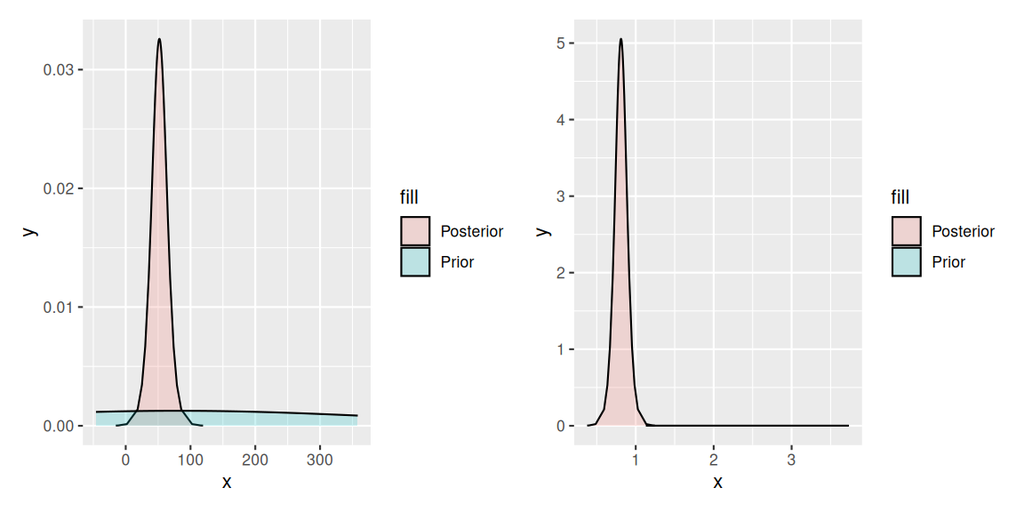

```r
p <- vector("list", length(nm))
for (wch in 1:length(nm)) {
  xy <- INLA:::inla.get.prior.xy(
    section = "fixed", hyperid = nm[1],
    all.hyper = fert.inla1$all.hyper,
    range = 3 * range(marg.fix[[wch]][, "x"])
  )
  p[[wch]] <- ggplot() +
    geom_density(
      data = as.data.frame(marg.fix[[wch]]),
      aes(x = x, y = y, fill = "Posterior"), alpha = 0.2,
      stat = "Identity"
    ) +
    geom_density(
      data = as.data.frame(xy), aes(x = x, y = y, fill = "Prior"), alpha = 0.2,
      stat = "Identity"
    )
}
patchwork::wrap_plots(p)
```

# 6 MCMC sampling diagnostics

**MCMC sampling behaviour**

Since the purpose of the MCMC sampling is to estimate the posterior of an unknown joint likelihood, it is important that we explore a range of diagnostics designed to help identify when the resulting likelihood might not be accurate.

- **traceplots** - plots of the individual draws in sequence. Traces that resemble noise suggest that all likelihood features are likely to have be traversed. Obvious steps or blocks of noise are likely to represent distinct features and could imply that there are yet other features that have not yet been traversed - necessitating additional iterations. Furthermore, each chain should be indistinguishable from the others
- **autocorrelation function** - plots of the degree of correlation between pairs of draws for a range of lags (distance along the chains). High levels of correlation (after a lag of 0, which is correlating each draw with itself) suggests a lack of independence between the draws and that therefore, summaries such as mean and median will be biased estimates. Ideally, all non-zero lag correlations should be less than 0.2.
- **convergence diagnostics** - there are a range of diagnostics aimed at exploring whether the multiple chains are likely to have converged upon similar posteriors
  - **R hat** - this metric compares between and within chain model parameter estimates, with the expectation that if the chains have converged, the between and within rank normalised estimates should be very similar (and Rhat should be close to 1). The more one chains deviates from the others, the higher the Rhat value. Values less than 1.05 are considered evidence of convergence.
  - **Bulk ESS** - this is a measure of the effective sample size from the whole (bulk) of the posterior and is a good measure of the sampling efficiency of draws across the entire posterior
  - **Tail ESS** - this is a measure of the effective sample size from the 5% and 95% quantiles (tails) of the posterior and is a good measure of the sampling efficiency of draws from the tail (areas of the posterior with least support and where samplers can get stuck).

`available_mcmc()`

| Package | Description | function | rstanarm | brms |
| --- | --- | --- | --- | --- |
| bayesplot | Traceplot | `mcmc_trace` | `plot(mod, plotfun='trace')` | `mcmc_plot(mod, type='trace')` |
|  | Density plot | `mcmc_dens` | `plot(mod, plotfun='dens')` | `mcmc_plot(mod, type='dens')` |
|  | Density & Trace | `mcmc_combo` | `plot(mod, plotfun='combo')` | `mcmc_plot(mod, type='combo')` |
|  | ACF | `mcmc_acf_bar` | `plot(mod, plotfun='acf_bar')` | `mcmc_plot(mod, type='acf_bar')` |
|  | Rhat hist | `mcmc_rhat_hist` | `plot(mod, plotfun='rhat_hist')` | `mcmc_plot(mod, type='rhat_hist')` |
|  | No. Effective | `mcmc_neff_hist` | `plot(mod, plotfun='neff_hist')` | `mcmc_plot(mod, type='neff_hist')` |
| rstan | Traceplot | `stan_trace` | `stan_trace(mod)` | `stan_trace(mod)` |
|  | ACF | `stan_ac` | `stan_ac(mod)` | `stan_ac(mod)` |
|  | Rhat | `stan_rhat` | `stan_rhat(mod)` | `stan_rhat(mod)` |
|  | No. Effective | `stan_ess` | `stan_ess(mod)` | `stan_ess(mod)` |
|  | Density plot | `stan_dens` | `stan_dens(mod)` | `stan_dens(mod)` |
| ggmcmc | Traceplot | `ggs_traceplot` | `ggs_traceplot(ggs(mod))` | `ggs_traceplot(ggs(mod))` |
|  | ACF | `ggs_autocorrelation` | `ggs_autocorrelation(ggs(mod))` | `ggs_autocorrelation(ggs(mod))` |
|  | Rhat | `ggs_Rhat` | `ggs_Rhat(ggs(mod))` | `ggs_Rhat(ggs(mod))` |
|  | No. Effective | `ggs_effective` | `ggs_effective(ggs(mod))` | `ggs_effective(ggs(mod))` |
|  | Cross correlation | `ggs_crosscorrelation` | `ggs_crosscorrelation(ggs(mod))` | `ggs_crosscorrelation(ggs(mod))` |
|  | Scale reduction | `ggs_grb` | `ggs_grb(ggs(mod))` | `ggs_grb(ggs(mod))` |

In addition to the regular model diagnostics checking, for Bayesian analyses, it is also necessary to explore the MCMC sampling diagnostics to be sure that the chains are well mixed and have converged on a stable posterior.

There are a wide variety of tests that range from the big picture, overall chain characteristics to the very specific detailed tests that allow the experienced modeller to drill down to the very fine details of the chain behaviour. Furthermore, there are a multitude of packages and approaches for exploring these diagnostics.

**rstanarm**

**bayesplot**

The `bayesplot` package offers a range of MCMC diagnostics as well as Posterior Probability Checks (PPC), all of which have a convenient `plot()` interface. Lets start with the MCMC diagnostics.

```r
available_mcmc()
```

```
bayesplot MCMC module:
  mcmc_acf
  mcmc_acf_bar
  mcmc_areas
  mcmc_areas_ridges
  mcmc_combo
  mcmc_dens
  mcmc_dens_chains
  mcmc_dens_overlay
  mcmc_hex
  mcmc_hist
  mcmc_hist_by_chain
  mcmc_intervals
  mcmc_neff
  mcmc_neff_hist
  mcmc_nuts_acceptance
  mcmc_nuts_divergence
  mcmc_nuts_energy
  mcmc_nuts_stepsize
  mcmc_nuts_treedepth
  mcmc_pairs
  mcmc_parcoord
  mcmc_rank_ecdf
  mcmc_rank_hist
  mcmc_rank_overlay
  mcmc_recover_hist
  mcmc_recover_intervals
  mcmc_recover_scatter
  mcmc_rhat
  mcmc_rhat_hist
  mcmc_scatter
  mcmc_trace
  mcmc_trace_highlight
  mcmc_violin
```

Of these, we will focus on:

- mcmc_trace: this plots the estimates of each parameter over the post-warmup length of each MCMC chain. Each chain is plotted in a different shade of blue, with each parameter in its own facet. Ideally, each **trace** should just look like noise without any discernible drift and each of the traces for a specific parameter should look the same (i.e, should not be displaced above or below any other trace for that parameter).

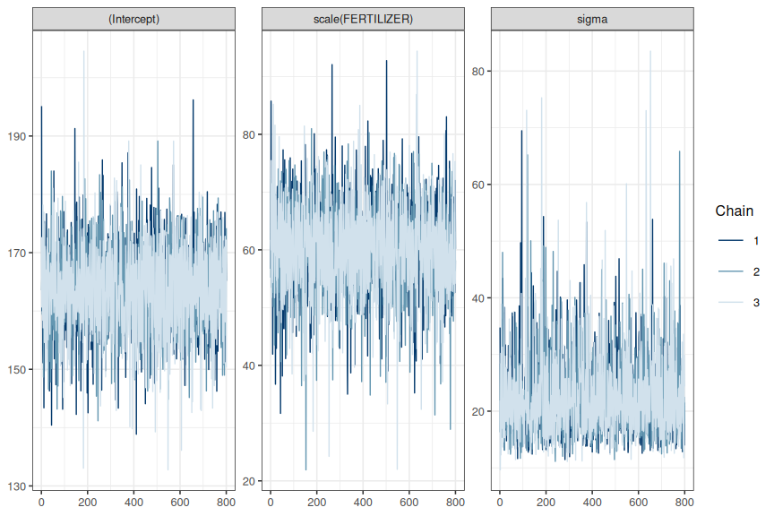

```r
plot(fert.rstanarm3, plotfun = "mcmc_trace")
```

The chains appear well mixed and very similar

- acf (autocorrelation function): plots the autocorrelation between successive MCMC sample lags for each parameter and each chain

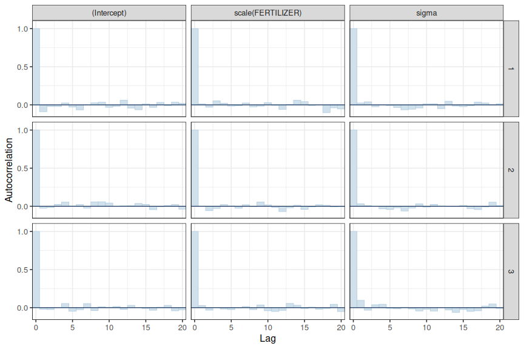

```r
plot(fert.rstanarm3, "acf_bar")
```

There is no evidence of autocorrelation in the MCMC samples

- Rhat: Rhat is a measure of convergence between the chains. The closer the values are to 1, the more the chains have converged. Values greater than 1.05 indicate a lack of convergence. There will be an Rhat value for each parameter estimated.

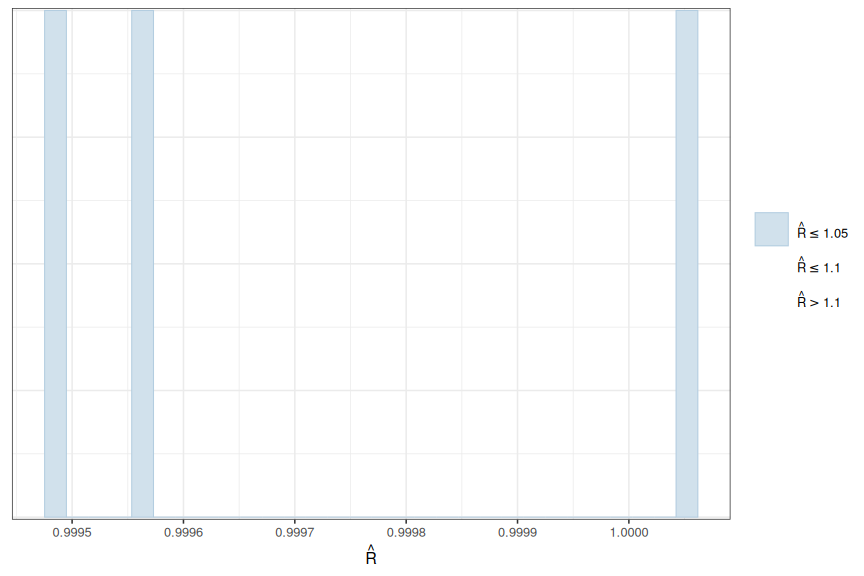

```r
plot(fert.rstanarm3, "rhat_hist")
```

All Rhat values are below 1.05, suggesting the chains have converged.

- neff (number of effective samples): the ratio of the number of effective samples (those not rejected by the sampler) to the number of samples provides an indication of the effectiveness (and efficiency) of the MCMC sampler. Ratios that are less than 0.5 for a parameter suggest that the sampler spent considerable time in difficult areas of the sampling domain and rejected more than half of the samples (replacing them with the previous effective sample).

  If the ratios are low, tightening the priors may help.

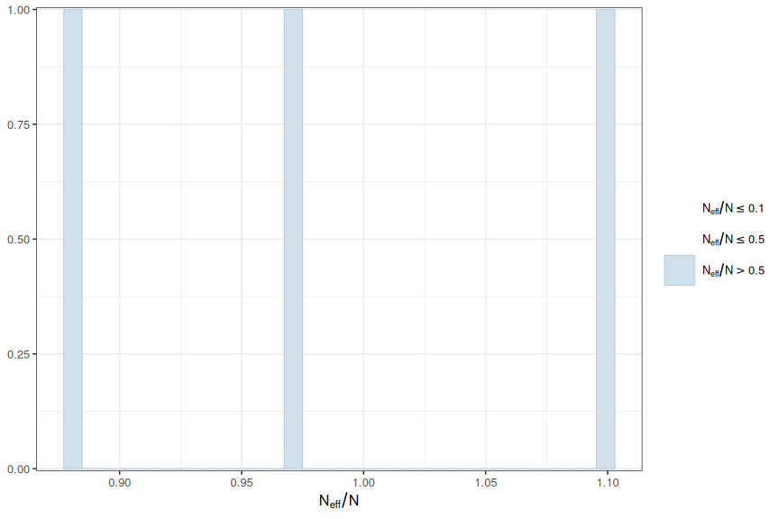

```r
plot(fert.rstanarm3, "neff_hist")
```

Ratios all very high.

**More diagnostics**

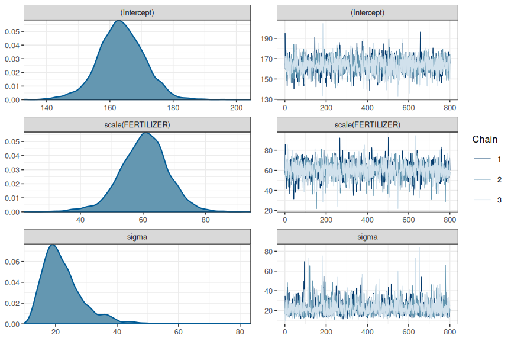

```r
plot(fert.rstanarm3, "combo")
```

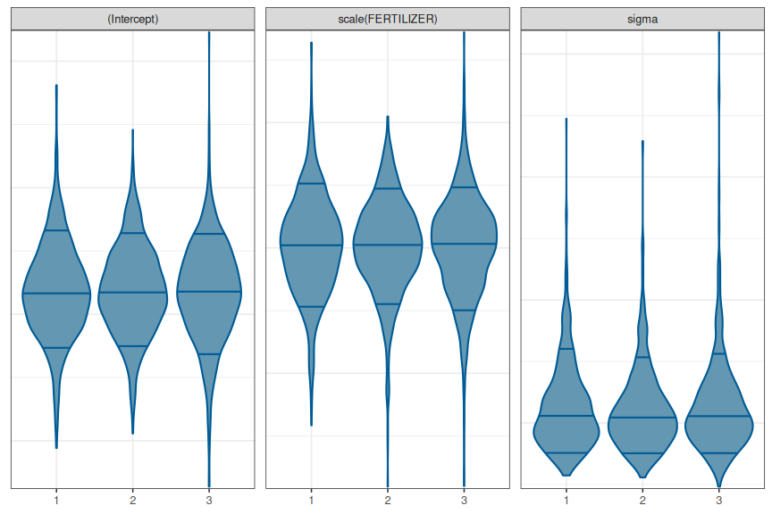

```r
plot(fert.rstanarm3, "violin")
```

**stan plots**

The `rstan` package offers a range of MCMC diagnostics. Lets start with the MCMC diagnostics.

Of these, we will focus on:

- stan_trace: this plots the estimates of each parameter over the post-warmup length of each MCMC chain. Each chain is plotted in a different colour, with each parameter in its own facet. Ideally, each **trace** should just look like noise without any discernible drift and each of the traces for a specific parameter should look the same (i.e, should not be displaced above or below any other trace for that parameter).

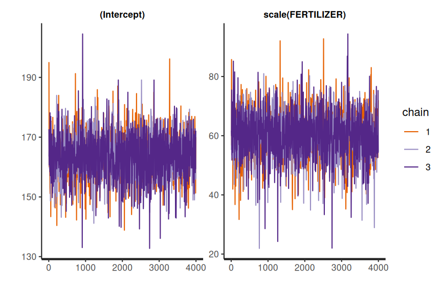

```r
stan_trace(fert.rstanarm3)
```

The chains appear well mixed and very similar

- stan_acf (autocorrelation function): plots the autocorrelation between successive MCMC sample lags for each parameter and each chain

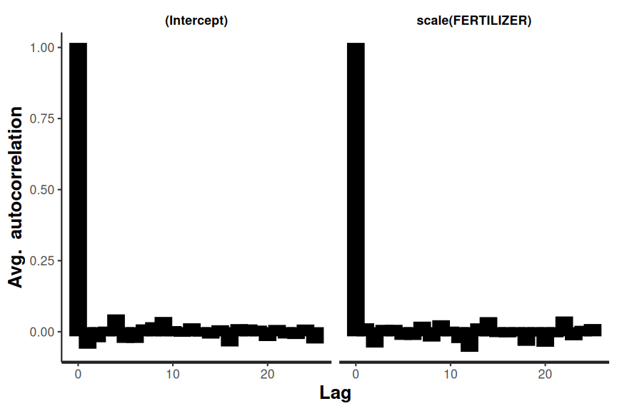

```r
stan_ac(fert.rstanarm3)
```

There is no evidence of autocorrelation in the MCMC samples

- stan_rhat: Rhat is a **scale reduction factor** measure of convergence between the chains. The closer the values are to 1, the more the chains have converged. Values greater than 1.05 indicate a lack of convergence. There will be an Rhat value for each parameter estimated.

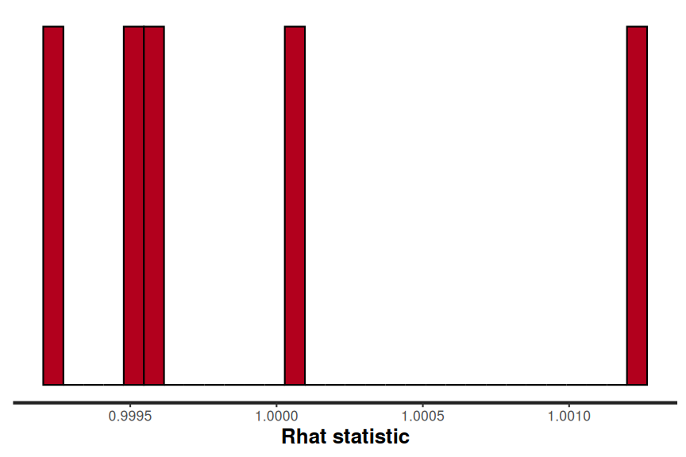

```r
stan_rhat(fert.rstanarm3)
```

All Rhat values are below 1.05, suggesting the chains have converged.

- stan_ess (number of effective samples): the ratio of the number of effective samples (those not rejected by the sampler) to the number of samples provides an indication of the effectiveness (and efficiency) of the MCMC sampler. Ratios that are less than 0.5 for a parameter suggest that the sampler spent considerable time in difficult areas of the sampling domain and rejected more than half of the samples (replacing them with the previous effective sample).

  If the ratios are low, tightening the priors may help.

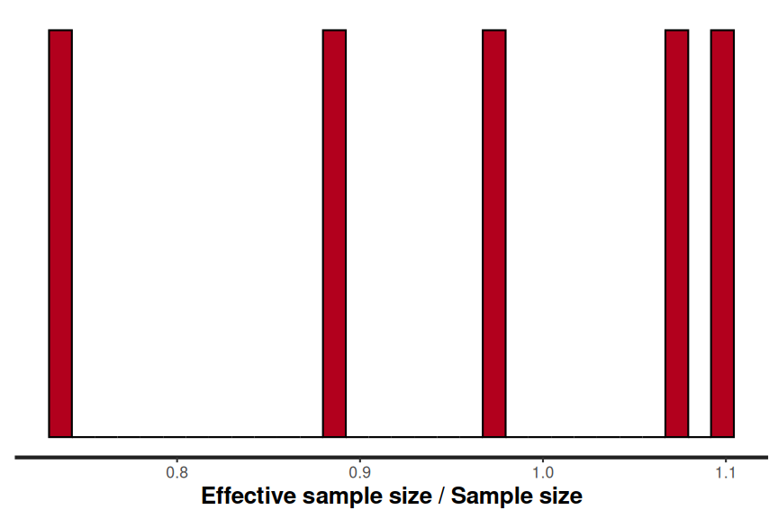

```r
stan_ess(fert.rstanarm3)
```

Ratios all very high.

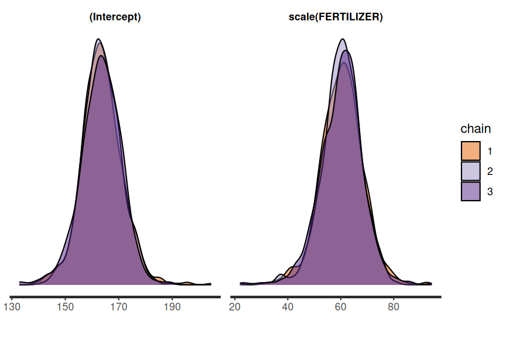

```r
stan_dens(fert.rstanarm3, separate_chains = TRUE)
```

**ggmcmc**

The `ggmean` package also has a set of MCMC diagnostic functions. Lets start with the MCMC diagnostics.

Of these, we will focus on:

- ggs_traceplot: this plots the estimates of each parameter over the post-warmup length of each MCMC chain. Each chain is plotted in a different colour, with each parameter in its own facet. Ideally, each **trace** should just look like noise without any discernible drift and each of the traces for a specific parameter should look the same (i.e, should not be displaced above or below any other trace for that parameter).

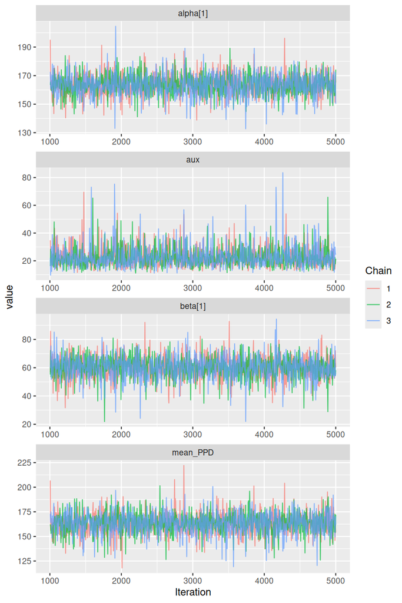

```r
fert.ggs <- ggs(fert.rstanarm3)
ggs_traceplot(fert.ggs)
```

The chains appear well mixed and very similar

- gss_autocorrelation (autocorrelation function): plots the autocorrelation between successive MCMC sample lags for each parameter and each chain

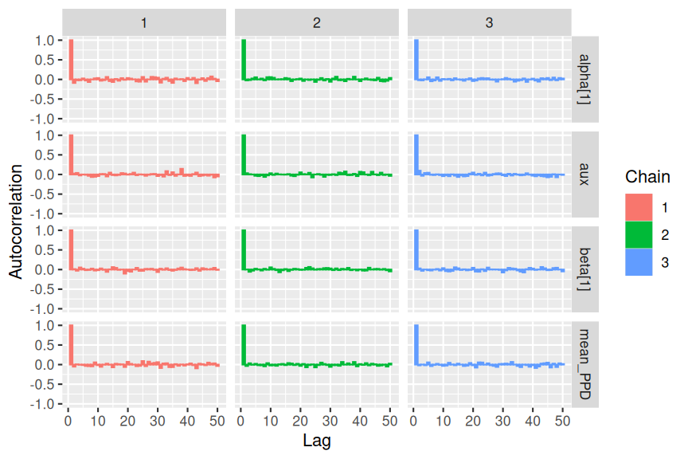

```r
ggs_autocorrelation(fert.ggs)
```

There is no evidence of autocorrelation in the MCMC samples

- stan_rhat: Rhat is a **scale reduction factor** measure of convergence between the chains. The closer the values are to 1, the more the chains have converged. Values greater than 1.05 indicate a lack of convergence. There will be an Rhat value for each parameter estimated.

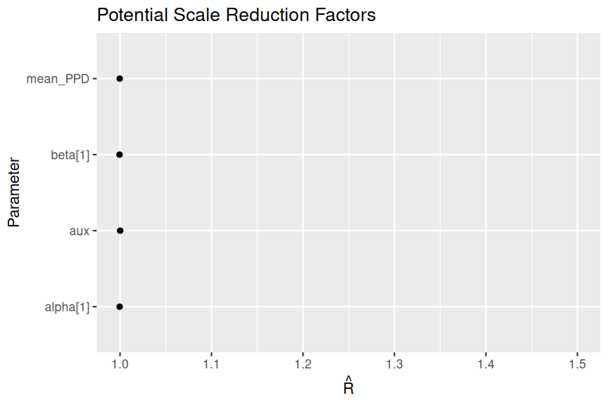

```r
ggs_Rhat(fert.ggs)
```

All Rhat values are below 1.05, suggesting the chains have converged.

- stan_ess (number of effective samples): the ratio of the number of effective samples (those not rejected by the sampler) to the number of samples provides an indication of the effectiveness (and efficiency) of the MCMC sampler. Ratios that are less than 0.5 for a parameter suggest that the sampler spent considerable time in difficult areas of the sampling domain and rejected more than half of the samples (replacing them with the previous effective sample).

  If the ratios are low, tightening the priors may help.

[figure not shown]

```r
ggs_effective(fert.ggs)
```

**More diagnostics**

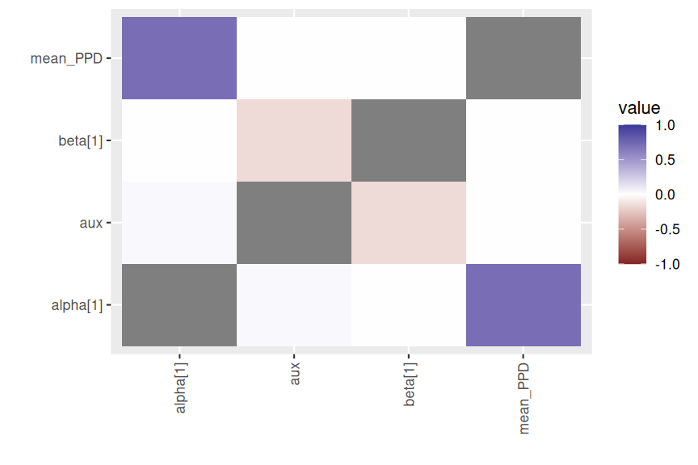

```r
ggs_crosscorrelation(fert.ggs)
```

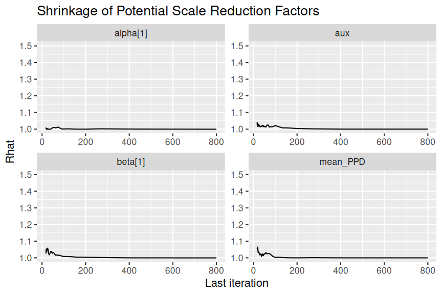

```r
ggs_grb(fert.ggs)
```

**brms**

**bayesplot**

The `bayesplot` package offers a range of MCMC diagnostics as well as Posterior Probability Checks (PPC), all of which have a convenient `plot()` interface. Lets start with the MCMC diagnostics.

```r
available_mcmc()
```

```
bayesplot MCMC module:
  mcmc_acf
  mcmc_acf_bar
  mcmc_areas
  mcmc_areas_ridges
  mcmc_combo
  mcmc_dens
  mcmc_dens_chains
  mcmc_dens_overlay
  mcmc_hex
  mcmc_hist
  mcmc_hist_by_chain
  mcmc_intervals
  mcmc_neff
  mcmc_neff_hist
  mcmc_nuts_acceptance
  mcmc_nuts_divergence
  mcmc_nuts_energy
  mcmc_nuts_stepsize
  mcmc_nuts_treedepth
  mcmc_pairs
  mcmc_parcoord
  mcmc_rank_ecdf
  mcmc_rank_hist
  mcmc_rank_overlay
  mcmc_recover_hist
  mcmc_recover_intervals
  mcmc_recover_scatter
  mcmc_rhat
  mcmc_rhat_hist
  mcmc_scatter
  mcmc_trace
  mcmc_trace_highlight
  mcmc_violin
```

Of these, we will focus on:

- trace: this plots the estimates of each parameter over the post-warmup length of each MCMC chain. Each chain is plotted in a different shade of blue, with each parameter in its own facet. Ideally, each **trace** should just look like noise without any discernible drift and each of the traces for a specific parameter should look the same (i.e, should not be displaced above or below any other trace for that parameter).

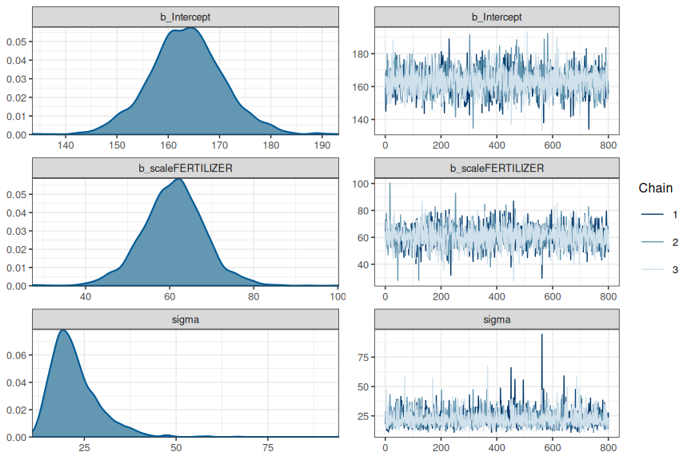

```r
fert_brm3 |> mcmc_plot(type = "combo")
```

```
No divergences to plot.
```

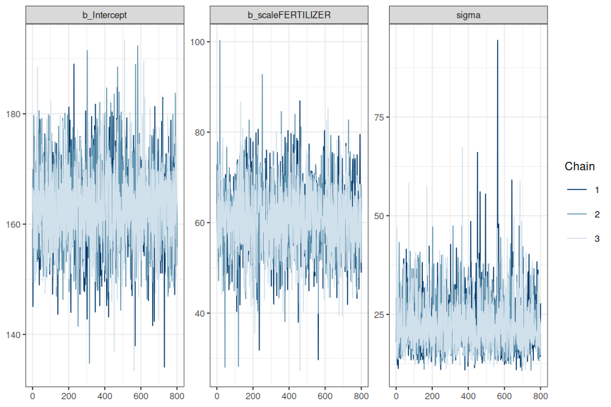

```r
fert_brm3 |> mcmc_plot(type = "trace")
```

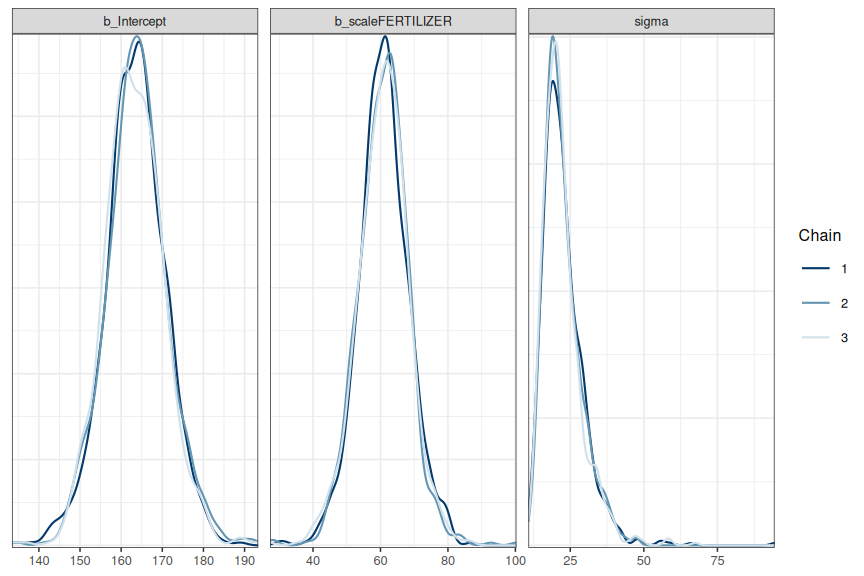

```r
fert_brm3 |> mcmc_plot(type = "dens_overlay")
```

[figure not shown]

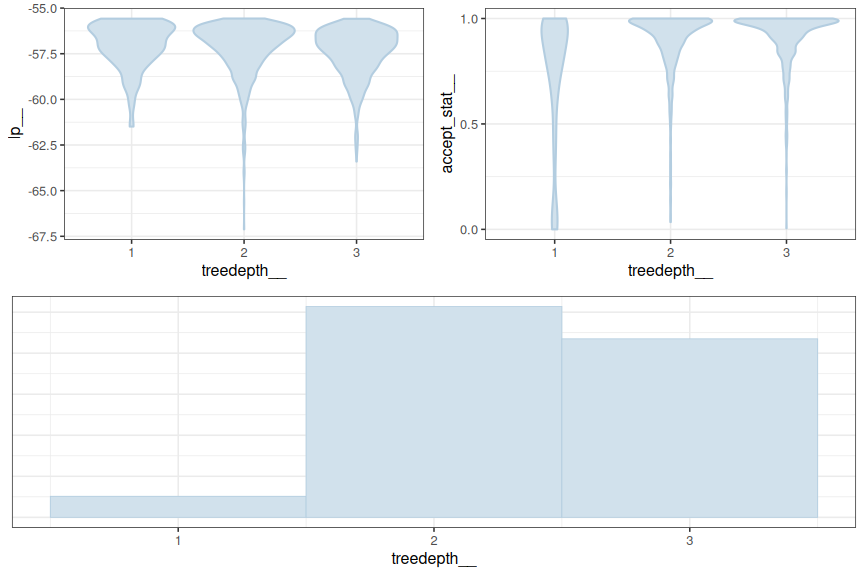

```r
fert_brm3 |> mcmc_plot(type = "nuts_treedepth")
```

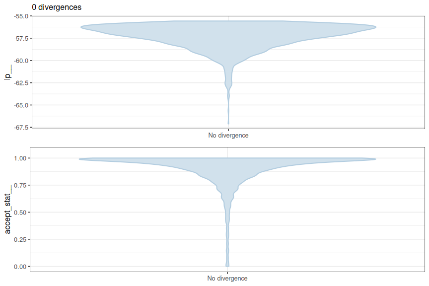

```r
fert_brm3 |> mcmc_plot(type = "nuts_divergence")
```

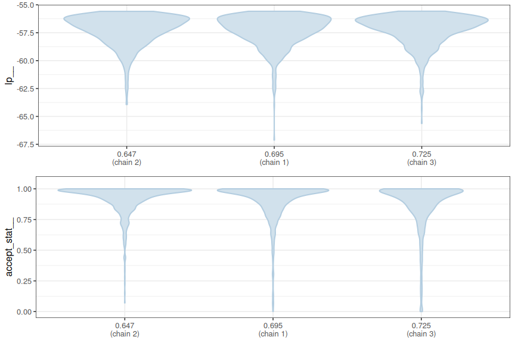

```r
fert_brm3 |> mcmc_plot(type = "nuts_stepsize")
```

The chains appear well mixed and very similar

- acf_bar (autocorrelation function): plots the autocorrelation between successive MCMC sample lags for each parameter and each chain

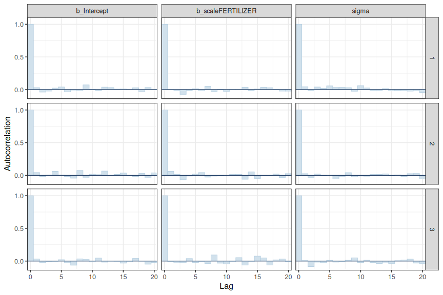

```r
fert_brm3 |> mcmc_plot(type = "acf_bar")
```

There is no evidence of autocorrelation in the MCMC samples

- rhat_hist: Rhat is a **scale reduction factor** measure of convergence between the chains. The closer the values are to 1, the more the chains have converged. Values greater than 1.05 indicate a lack of convergence. There will be an Rhat value for each parameter estimated.

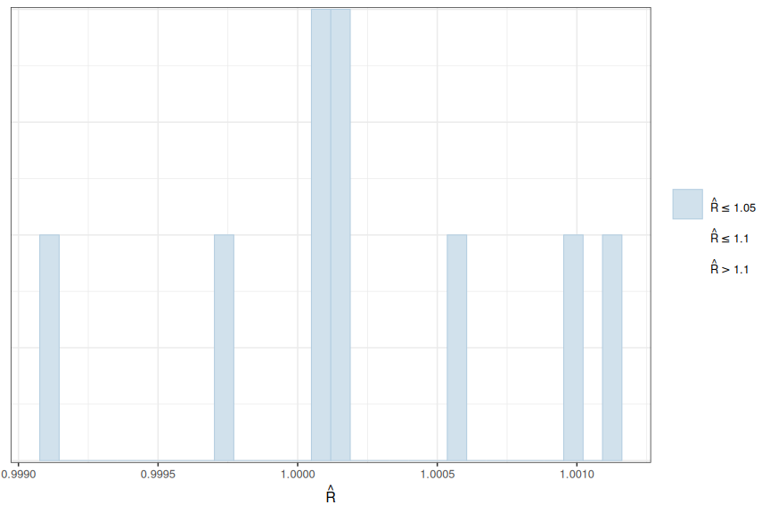

```r
fert_brm3 |> mcmc_plot(type = "rhat_hist")
```

All Rhat values are below 1.05, suggesting the chains have converged.

- neff_hist (number of effective samples): the ratio of the number of effective samples (those not rejected by the sampler) to the number of samples provides an indication of the effectiveness (and efficiency) of the MCMC sampler. Ratios that are less than 0.5 for a parameter suggest that the sampler spent considerable time in difficult areas of the sampling domain and rejected more than half of the samples (replacing them with the previous effective sample).

  If the ratios are low, tightening the priors may help.

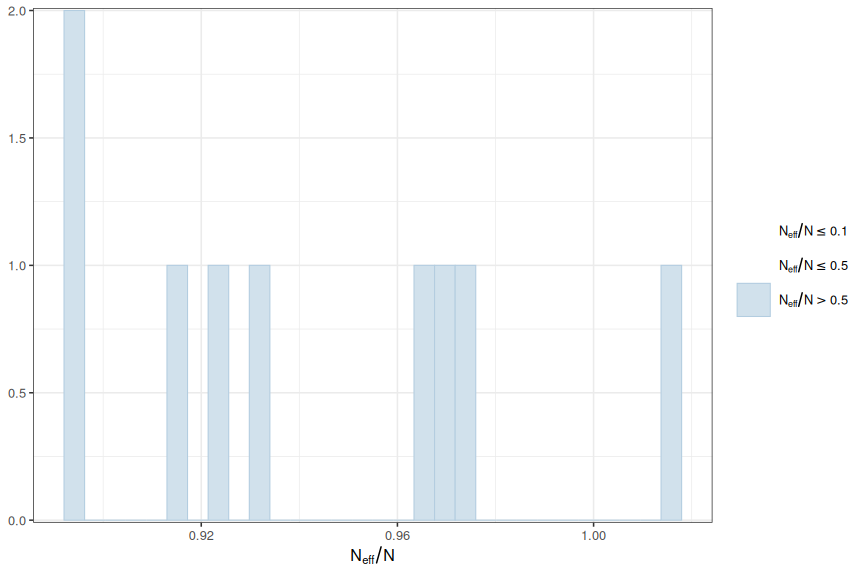

```r
fert_brm3 |> mcmc_plot(type = "neff_hist")
```

Ratios all very high.

**More diagnostics**

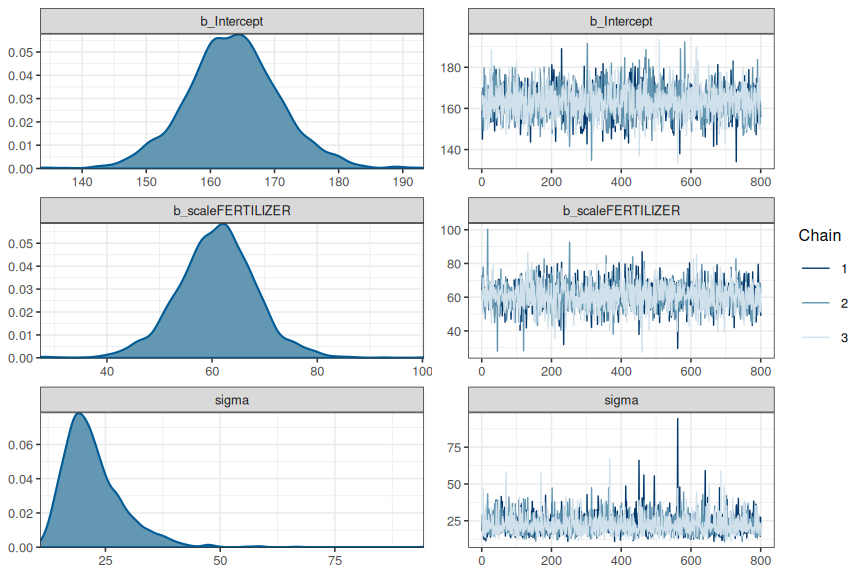

```r
fert_brm3 |> mcmc_plot(type = "combo")
```

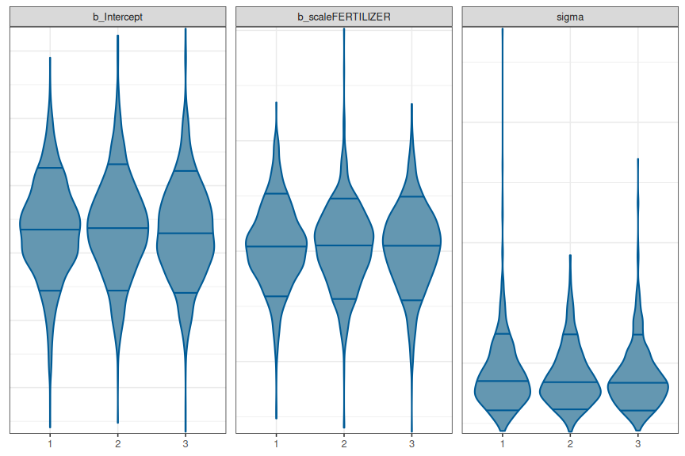

```r
fert_brm3 |> mcmc_plot(type = "violin")
```

**stan plots**

The `rstan` package offers a range of MCMC diagnostics. Lets start with the MCMC diagnostics.

Of these, we will focus on:

- stan_trace: this plots the estimates of each parameter over the post-warmup length of each MCMC chain. Each chain is plotted in a different colour, with each parameter in its own facet. Ideally, each **trace** should just look like noise without any discernible drift and each of the traces for a specific parameter should look the same (i.e, should not be displaced above or below any other trace for that parameter).

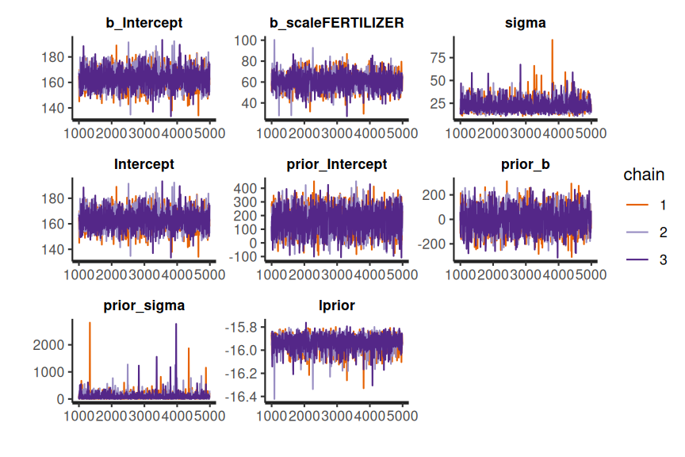

```r
stan_trace(fert_brm3$fit)
```

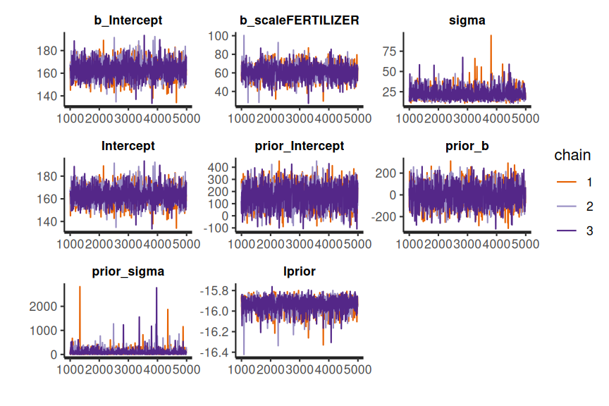

```r
fert_brm3$fit |> stan_trace()
```

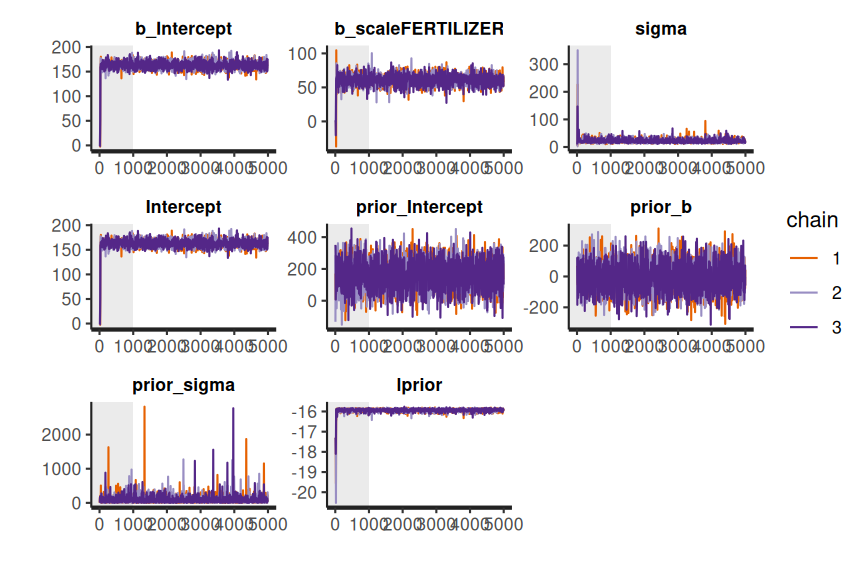

```r
fert_brm3$fit |> stan_trace(inc_warmup = TRUE)
```

The chains appear well mixed and very similar

- stan_acf (autocorrelation function): plots the autocorrelation between successive MCMC sample lags for each parameter and each chain

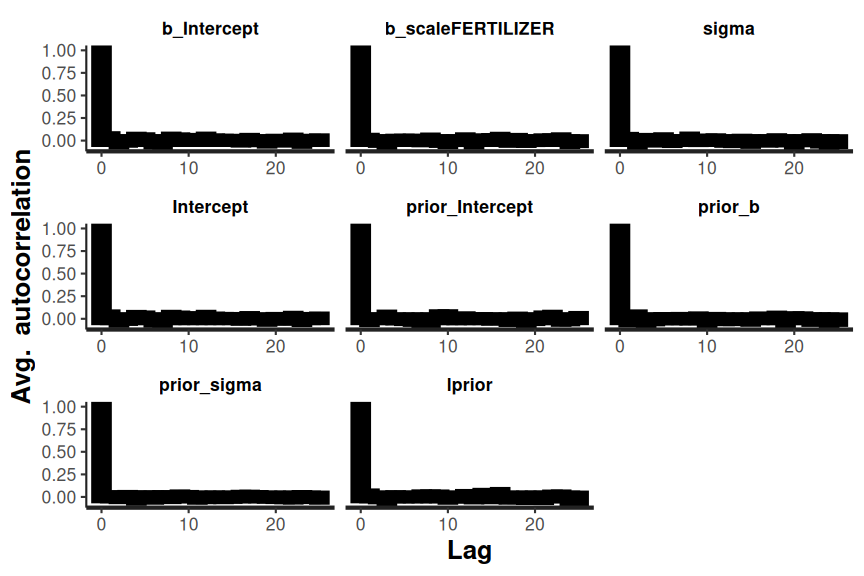

```r
fert_brm3$fit |> stan_ac()
```

There is no evidence of autocorrelation in the MCMC samples

- stan_rhat: Rhat is a **scale reduction factor** measure of convergence between the chains. The closer the values are to 1, the more the chains have converged. Values greater than 1.05 indicate a lack of convergence. There will be an Rhat value for each parameter estimated.

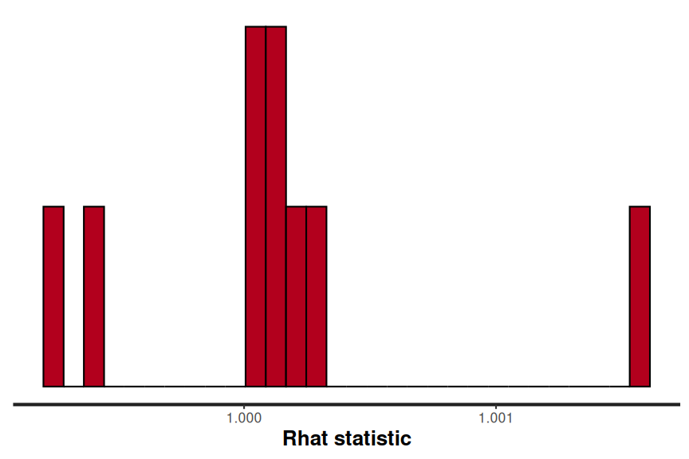

```r
fert_brm3$fit |> stan_rhat()
```

All Rhat values are below 1.05, suggesting the chains have converged.

- stan_ess (number of effective samples): the ratio of the number of effective samples (those not rejected by the sampler) to the number of samples provides an indication of the effectiveness (and efficiency) of the MCMC sampler. Ratios that are less than 0.5 for a parameter suggest that the sampler spent considerable time in difficult areas of the sampling domain and rejected more than half of the samples (replacing them with the previous effective sample).

  If the ratios are low, tightening the priors may help.

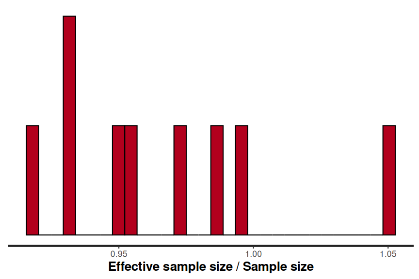

```r
fert_brm3$fit |> stan_ess()
```

Ratios all very high.

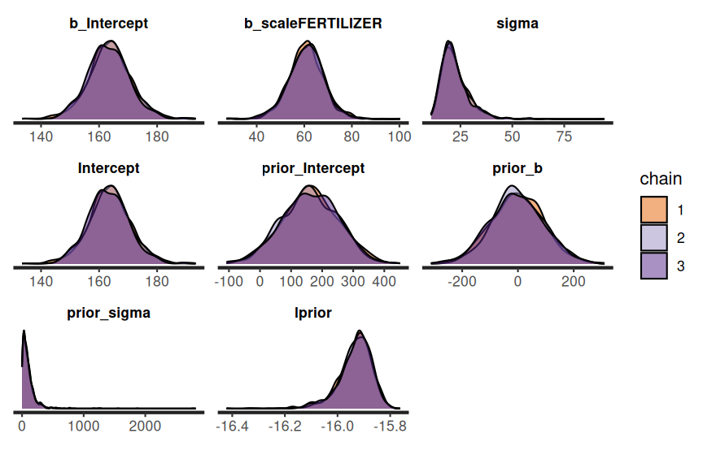

```r
fert_brm3$fit |> stan_dens(separate_chains = TRUE)
```

**ggmcmc**

The `ggmcmc` package also has a set of MCMC diagnostic functions. Lets start with the MCMC diagnostics.

Of these, we will focus on:

- ggs_traceplot: this plots the estimates of each parameter over the post-warmup length of each MCMC chain. Each chain is plotted in a different colour, with each parameter in its own facet. Ideally, each **trace** should just look like noise without any discernible drift and each of the traces for a specific parameter should look the same (i.e, should not be displaced above or below any other trace for that parameter).

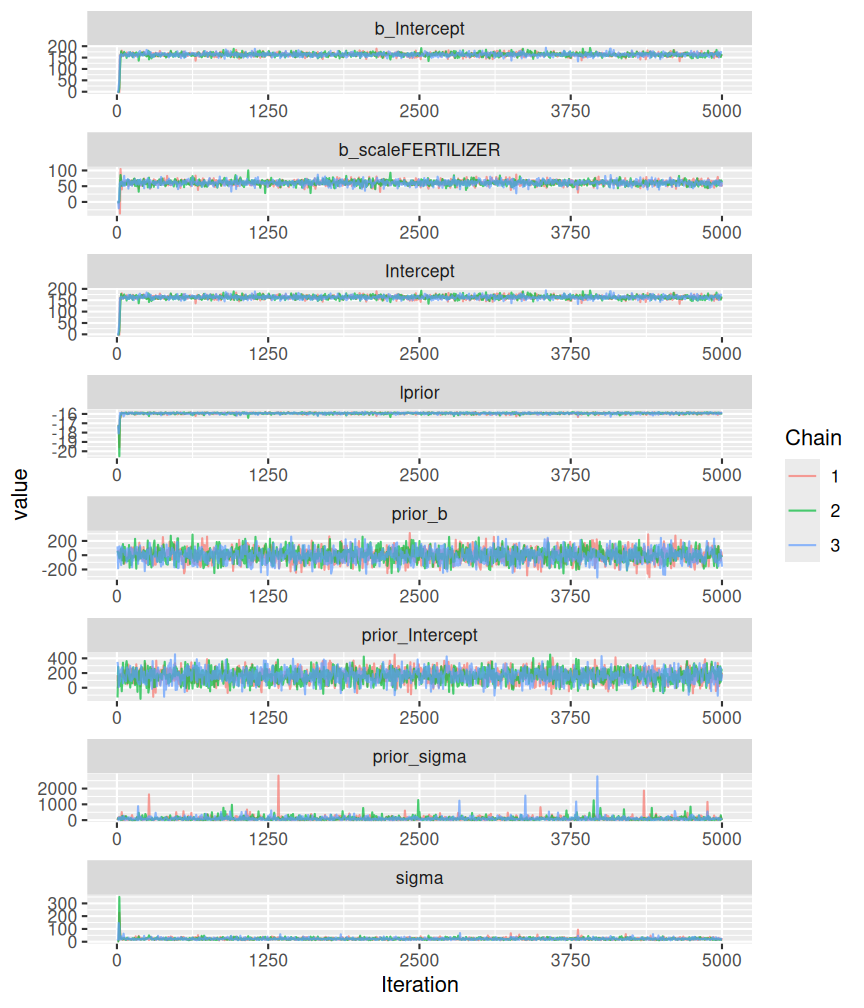

```r
fert.ggs <- fert_brm3$fit |> ggs(inc_warmup = TRUE, burnin = TRUE) # does not seem to ignore burnin?
fert.ggs |> ggs_traceplot()
```

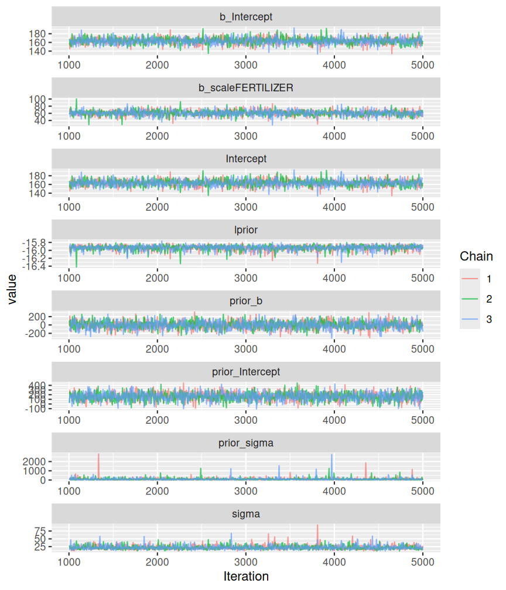

```r
fert.ggs <- fert_brm3$fit |> ggs(inc_warmup = FALSE, burnin = TRUE) # does not seem to ignore burnin?
fert.ggs |> ggs_traceplot()
```

The chains appear well mixed and very similar

- gss_autocorrelation (autocorrelation function): plots the autocorrelation between successive MCMC sample lags for each parameter and each chain

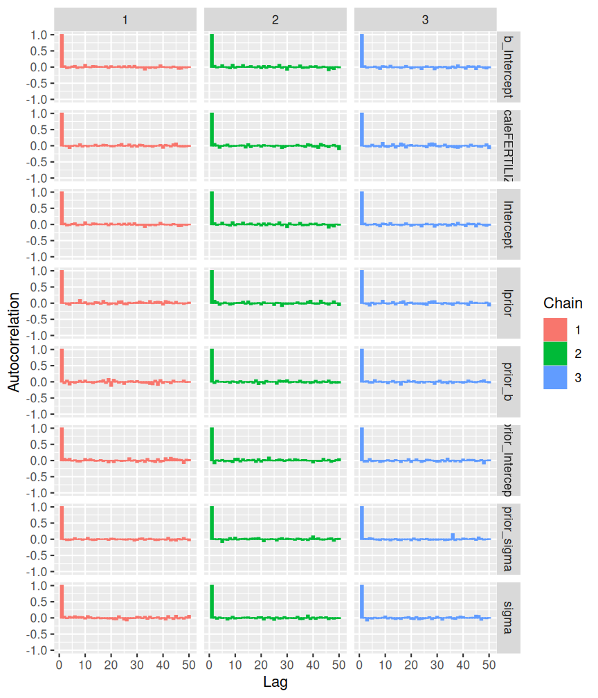

```r
fert.ggs |> ggs_autocorrelation()
```

There is no evidence of autocorrelation in the MCMC samples

- stan_rhat: Rhat is a **scale reduction factor** measure of convergence between the chains. The closer the values are to 1, the more the chains have converged. Values greater than 1.05 indicate a lack of convergence. There will be an Rhat value for each parameter estimated.

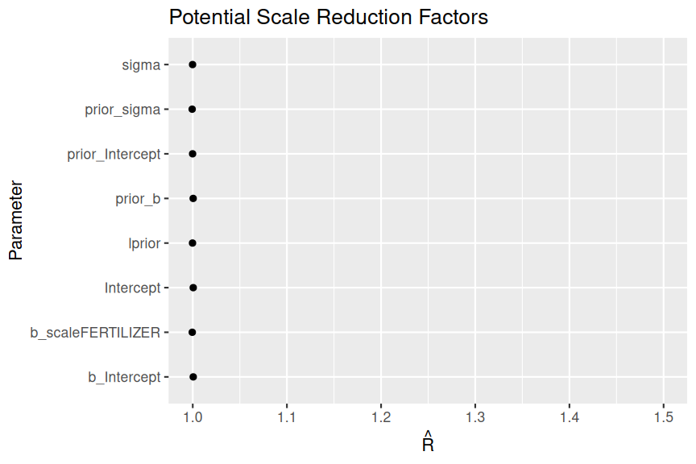

```r
fert.ggs |> ggs_Rhat()
```

All Rhat values are below 1.05, suggesting the chains have converged.

- stan_ess (number of effective samples): the ratio of the number of effective samples (those not rejected by the sampler) to the number of samples provides an indication of the effectiveness (and efficiency) of the MCMC sampler. Ratios that are less than 0.5 for a parameter suggest that the sampler spent considerable time in difficult areas of the sampling domain and rejected more than half of the samples (replacing them with the previous effective sample).

  If the ratios are low, tightening the priors may help.

[figure not shown]

```r
fert.ggs |> ggs_effective()
```

**More diagnostics**

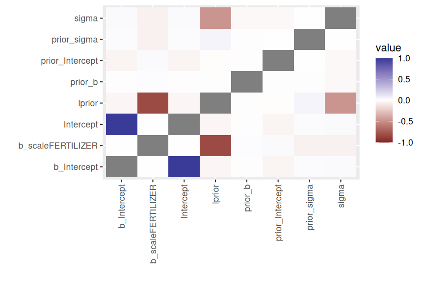

```r
fert.ggs |> ggs_crosscorrelation()
```

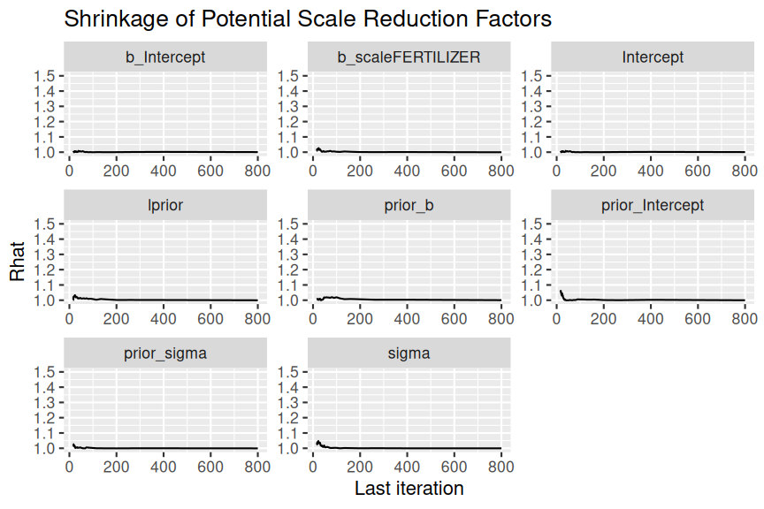

```r
fert.ggs |> ggs_grb()
```

**INLA**

The sampling diagnostics are not relevant to INLA. Instead, we can focus on CPO and PIT

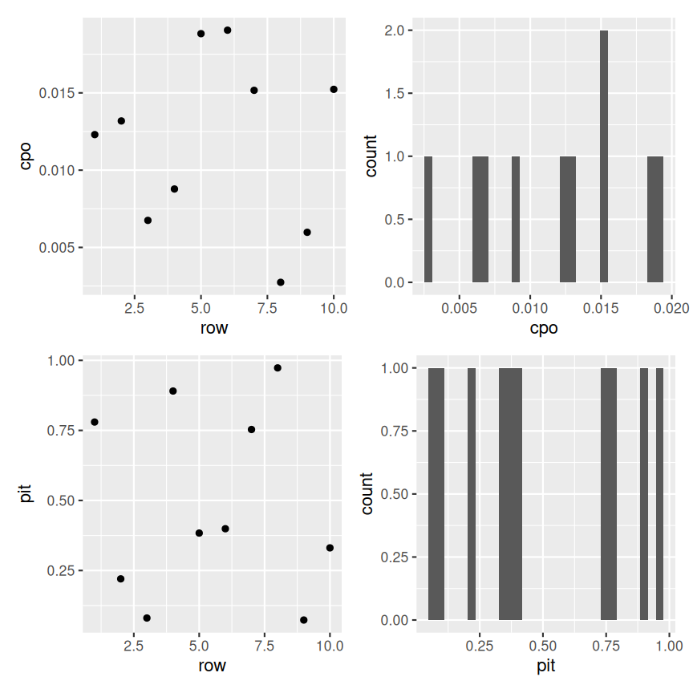

```r
fert.inla1.cpo <- data.frame(
  cpo = fert.inla1$cpo$cpo,
  pit = fert.inla1$cpo$pit,
  failure = fert.inla1$cpo$failure
) |>
  filter(failure == 0) |>
  mutate(row = 1:n())

g1 <- fert.inla1.cpo |>
  ggplot(aes(y = cpo, x = row)) +
  geom_point()
g2 <- fert.inla1.cpo |>
  ggplot(aes(x = cpo)) +
  geom_histogram()
g3 <- fert.inla1.cpo |>
  ggplot(aes(y = pit, x = row)) +
  geom_point()
g4 <- fert.inla1.cpo |>
  ggplot(aes(x = pit)) +
  geom_histogram()

(g1 + g2) / (g3 + g4)
```

Ideally, we want to see that no CPO or PIT is very different in value from any others (not the case here) and that the histograms are relatively flat (which they kind of are here - particularly considering the small amount of data).

# 7 Model validation

**Posterior probability checks**

`available_ppc()`

| Package | Description | function | rstanarm | brms |
| --- | --- | --- | --- | --- |
| bayesplot | Density overlay | `ppc_dens_overlay` | `pp_check(mod, plotfun='dens_overlay')` | `pp_check(mod, type='dens_overlay')` |
|  | Obs vs Pred error | `ppc_error_scatter_avg` | `pp_check(mod, plotfun='error_scatter_avg')` | `pp_check(mod, type='error_scatter_avg')` |
|  | Pred error vs x | `ppc_error_scatter_avg_vs_x` | `pp_check(mod, x=, plotfun='error_scatter_avg_vs_x')` | `pp_check(mod, x=, type='error_scatter_avg_vs_x')` |
|  | Preds vs x | `ppc_intervals` | `pp_check(mod, x=, plotfun='intervals')` | `pp_check(mod, x=, type='intervals')` |
|  | Partial plot | `ppc_ribbon` | `pp_check(mod, x=, plotfun='ribbon')` | `pp_check(mod, x=, type='ribbon')` |

**rstanarm**

**pp check**

Post predictive checks provide additional diagnostics about the fit of the model. Specifically, they provide a comparison between predictions drawn from the model and the observed data used to train the model.

```r
available_ppc()
```

```
bayesplot PPC module:
  ppc_bars
  ppc_bars_grouped
  ppc_boxplot
  ppc_dens
  ppc_dens_overlay
  ppc_dens_overlay_grouped
  ppc_dots
  ppc_ecdf_overlay
  ppc_ecdf_overlay_grouped
  ppc_error_binned
  ppc_error_hist
  ppc_error_hist_grouped
  ppc_error_scatter
  ppc_error_scatter_avg
  ppc_error_scatter_avg_grouped
  ppc_error_scatter_avg_vs_x
  ppc_freqpoly
  ppc_freqpoly_grouped
  ppc_hist
  ppc_intervals
  ppc_intervals_grouped
  ppc_km_overlay
  ppc_km_overlay_grouped
  ppc_loo_intervals
  ppc_loo_pit_ecdf
  ppc_loo_pit_overlay
  ppc_loo_pit_qq
  ppc_loo_ribbon
  ppc_pit_ecdf
  ppc_pit_ecdf_grouped
  ppc_ribbon
  ppc_ribbon_grouped
  ppc_rootogram
  ppc_scatter
  ppc_scatter_avg
  ppc_scatter_avg_grouped
  ppc_stat
  ppc_stat_2d
  ppc_stat_freqpoly
  ppc_stat_freqpoly_grouped
  ppc_stat_grouped
  ppc_violin_grouped
```

- dens_overlay: plots the density distribution of the observed data (black line) overlayed on top of 50 density distributions generated from draws from the model (light blue). Ideally, the 50 realisations should be roughly consistent with the observed data.

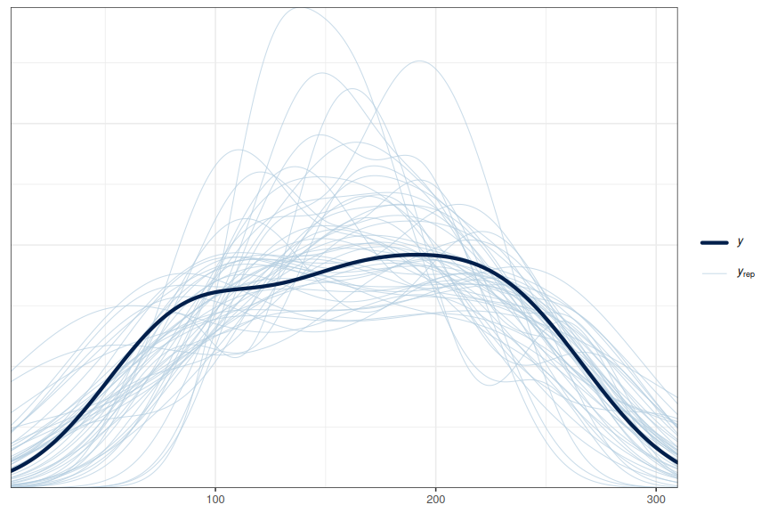

```r
pp_check(fert.rstanarm3, plotfun = "dens_overlay")
```

The model draws appear to be consistent with the observed data.

- error_scatter_avg: this plots the observed values against the average residuals. Similar to a residual plot, we do not want to see any patterns in this plot

```r
# pp_check(fert.rstanarm3, plotfun='error_scatter_avg')
```

- error_scatter_avg_vs_x: this is similar to a regular residual plot and as such should be interpreted as such.

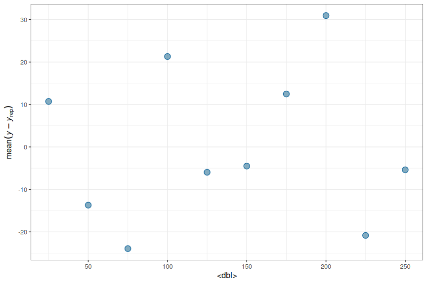

```r
pp_check(fert.rstanarm3, x = fert$FERTILIZER, plotfun = "error_scatter_avg_vs_x")
```

- intervals: plots the observed data overlayed onto of posterior predictions associated with each level of the predictor. Ideally, the observed data should all fall within the predictive intervals.

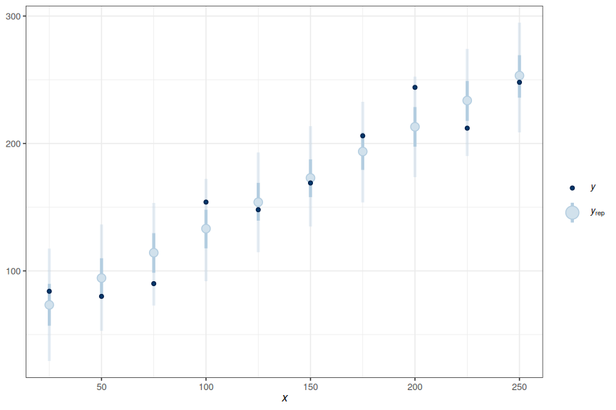

```r
pp_check(fert.rstanarm3, x = fert$FERTILIZER, plotfun = "intervals")
```

- ribbon: this is just an alternative way of expressing the above plot.

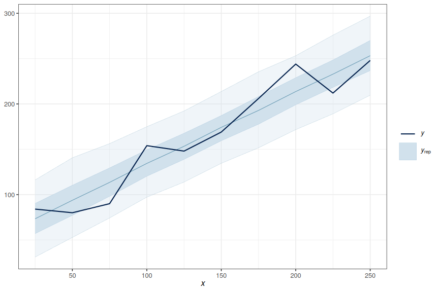

```r
pp_check(fert.rstanarm3, x = fert$FERTILIZER, plotfun = "ribbon")
```

The `shinystan` package allows the full suite of MCMC diagnostics and posterior predictive checks to be accessed via a web interface.

```r
# library(shinystan)
# launch_shinystan(fert.rstanarm3)
```

**DHARMa residuals**

DHARMa residuals provide very useful diagnostics. Unfortunately, we cannot directly use the `simulateResiduals()` function to generate the simulated residuals. However, if we are willing to calculate some of the components yourself, we can still obtain the simulated residuals from the fitted stan model.

We need to supply:

- simulated (predicted) responses associated with each observation.
- observed values
- fitted (predicted) responses (averaged) associated with each observation

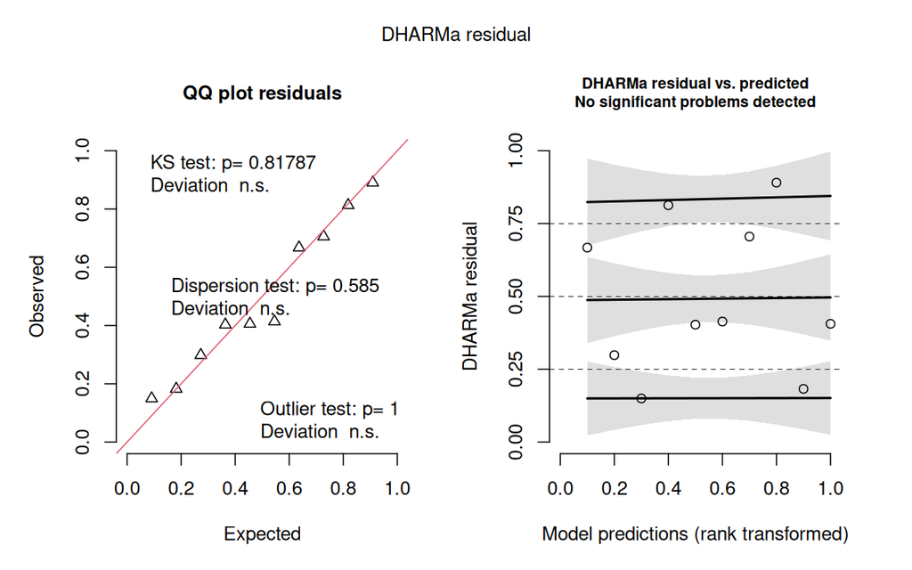

```r
preds <- posterior_predict(fert.rstanarm3, ndraws = 250, summary = FALSE)
fert.resids <- createDHARMa(
  simulatedResponse = t(preds),
  observedResponse = fert$YIELD,
  fittedPredictedResponse = apply(preds, 2, median),
  integerResponse = "gaussian"
)
plot(fert.resids)
```

**Conclusions:**

- the simulated residuals do not suggest any issues with the residuals
- there is no evidence of a lack of fit.

**brms**

**pp check**

Post predictive checks provide additional diagnostics about the fit of the model. Specifically, they provide a comparison between predictions drawn from the model and the observed data used to train the model.

```r
available_ppc()
```

```
bayesplot PPC module:
  ppc_bars
  ppc_bars_grouped
  ppc_boxplot
  ppc_dens
  ppc_dens_overlay
  ppc_dens_overlay_grouped
  ppc_dots
  ppc_ecdf_overlay
  ppc_ecdf_overlay_grouped
  ppc_error_binned
  ppc_error_hist
  ppc_error_hist_grouped
  ppc_error_scatter
  ppc_error_scatter_avg
  ppc_error_scatter_avg_grouped
  ppc_error_scatter_avg_vs_x
  ppc_freqpoly
  ppc_freqpoly_grouped
  ppc_hist
  ppc_intervals
  ppc_intervals_grouped
  ppc_km_overlay
  ppc_km_overlay_grouped
  ppc_loo_intervals
  ppc_loo_pit_ecdf
  ppc_loo_pit_overlay
  ppc_loo_pit_qq
  ppc_loo_ribbon
  ppc_pit_ecdf
  ppc_pit_ecdf_grouped
  ppc_ribbon
  ppc_ribbon_grouped
  ppc_rootogram
  ppc_scatter
  ppc_scatter_avg
  ppc_scatter_avg_grouped
  ppc_stat
  ppc_stat_2d
  ppc_stat_freqpoly
  ppc_stat_freqpoly_grouped
  ppc_stat_grouped
  ppc_violin_grouped
```

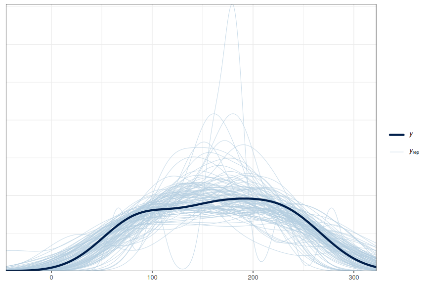

```r
fert_brm3 |> pp_check(type = "dens_overlay", ndraws = 100)
```

The model draws appear to be consistent with the observed data.

- error_scatter_avg: this plots the observed values against the average residuals. Similar to a residual plot, we do not want to see any patterns in this plot

```
Using all posterior draws for ppc type 'error_scatter_avg' by default.
```

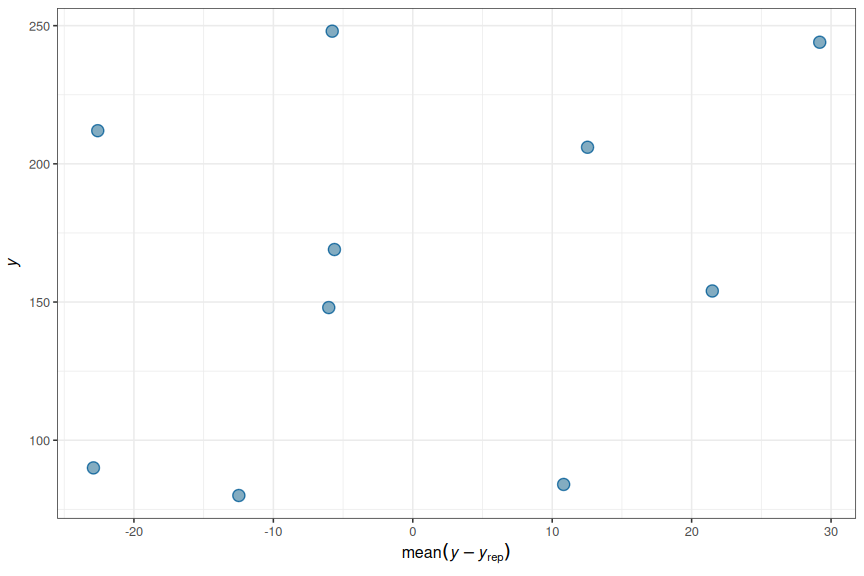

```r
fert_brm3 |> pp_check(type = "error_scatter_avg")
```

There is no obvious pattern in the residuals.